# Descriptive statistics by urban/rural area

Maggie Walters

June 16, 2017

## ANOVA with RMSP as a factor

```r
#list of each county
county_vec <- as.character(unique(data$COUNTY))
#create blank upper quartile matrix
upperq_matrix <- matrix(rep(NA, length(county_vec) * 12), nrow = 12, ncol = length(county_vec))
colnames(upperq_matrix) <- county_vec
months <- c("January", "Febuary", "March",
            "April", "May", "June",
            "July", "August", "September",
            "October", "November", "December")
row.names(upperq_matrix) <- months

#find upper quartile for each county in each month
for(i in 1:12){
  x <- subset(data, data$MONTH == i)
  for(j in 1:387){
    which.county_j <- which(x$COUNTY == county_vec[j])
    county_j_ages <- x$AGE[which.county_j]
    upperq_matrix[i,j] <- quantile(county_j_ages)[4]
  }
}
upper_matrix <- matrix(rep(NA, 4 * 12*length(county_vec)), ncol = 4)
colnames(upper_matrix) <- c("UPPER", "COUNTY", "MONTH", "RMSP")

#fill in upper
for(i in 1:12 * length(county_vec)){
  upper_matrix[,1] <- upperq_matrix[,]
}
#fill in months
upper_matrix[,3] <- rep(seq(1:12), length(county_vec))
#fill in counties
upper_matrix[seq(1,12),2] <- rep(county_vec[1], 12)
for(i in 1:49){
  x <- 12 * (i-1)
  upper_matrix[x + seq(1,12),2] <- rep(county_vec[i], 12)
}
#convert to data frame
upper_matrix <- as.data.frame(upper_matrix)

#isolate RMSPs
x <- rep(NA, length(county_vec))
for(i in 1:length(county_vec)){
  which.i <- which(data$COUNTY == county_vec[i])
  y <- rep(NA, length(which.i))
  y <- data$RMSP[which.i]
  x[i] <- mean(y)
}
rmsp_vec <- x

#fill in RMSPs
upper_matrix[seq(1,12),4] <- rep(rmsp_vec[1], 12)
for(i in 1:length(county_vec)){
  x <- 12 * (i-1)
  upper_matrix[x + seq(1,12),4] <- rep(rmsp_vec[i], 12)
}
```

[output not shown]

[output cut: 1105 more lines]

[output not shown]

```r
#remove NAs
upper_matrix <- subset(upper_matrix, !is.na(UPPER))

#change RMSP to a factor
upper_matrix$RMSP <- as.factor(upper_matrix$RMSP)

#change UPPER to a number
upper_matrix$UPPER <- as.numeric(upper_matrix$UPPER)

##rmsp_aov_mod <- aov(UPPER ~ RMSP, data = upper_matrix)

upper_mean_is <- subset(upper_matrix, upper_matrix$RMSP == 1)
y1 <- mean(upper_mean_is$UPPER)
x1 <- sd(upper_mean_is$UPPER)

upper_mean_not <- subset(upper_matrix, upper_matrix$RMSP == 0)
y2 <- mean(upper_mean_not$UPPER)
x2 <- sd(upper_mean_not$UPPER)

#sort by month for both
x <- order(upper_mean_is$MONTH)
upper_mean_is <- upper_mean_is[order(upper_mean_is$MONTH),]
```

### Preliminary analysis

- rmsp_aov_mod is not displaying a p-value, only sum of squares and degrees of freedom.
- In order to provide some sort of descriptive statistics here, the mean of those within the regional metropolitan area (RMSP = 1) is NaN and the standard deviation is NA.
- The mean of those not within the regional metropolitan area (RMSP = 0) is NaN and the standard deviation is NA.

**TO DO:**

- Sort by month regardless of county, so that progress of the epidemic within each county can be accounted for.
- Plot upper_mean_is (black) and upper_mean_not (red) in order to look for a visual trend/sign that there is a difference between counties within the regional metropolitan area and not within the regional metropolitan area.

## Divide counties by RMSP

```r
#list of each county
county_vec <- as.character(unique(data$COUNTY))

#are not in regional metropolitan area
rural <- subset(data, data$RMSP == 0)

#are in the regional metropolitan area
urban <- subset(data, data$RMSP == 1)
```

## Run ANOVA for county/month: UPPER

```r
upper_rural$UPPER <- as.numeric(upper_rural$UPPER)

####################################
#COUNTY
####################################
#p = 0.0322
upper_county_aov <- aov(UPPER ~ COUNTY, data = upper_rural)
#p = 6.897e-10, not normal
shapiro.test((resid(upper_county_aov)))
```

```
##
##  Shapiro-Wilk normality test
##
## data:  (resid(upper_county_aov))
## W = 0.98204, p-value = 6.897e-10
```

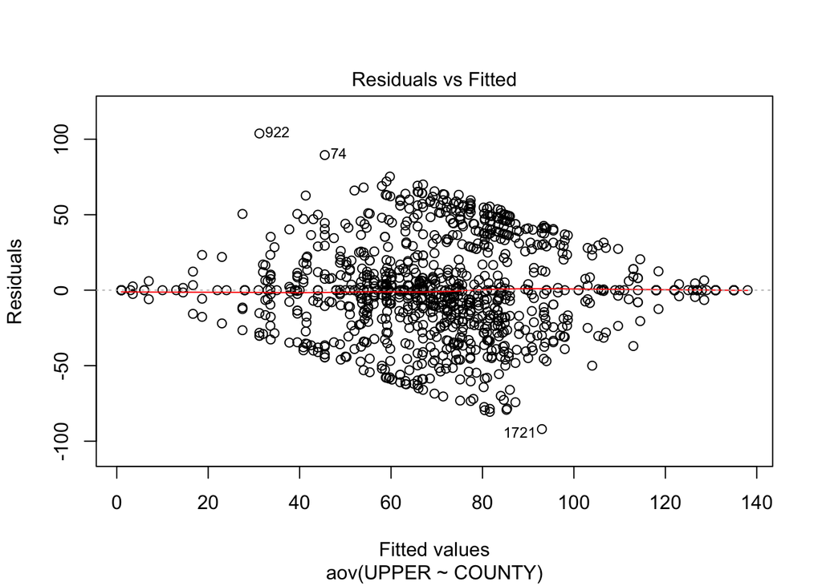

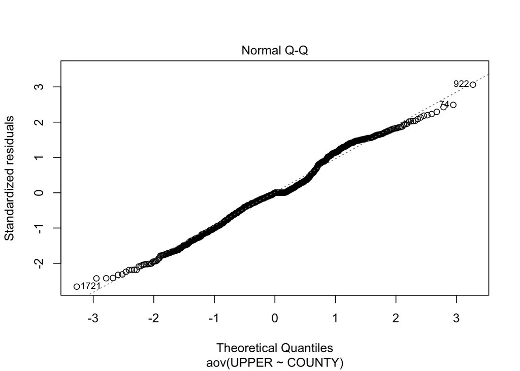

```r
plot(upper_county_aov, which = c(1,2))
```

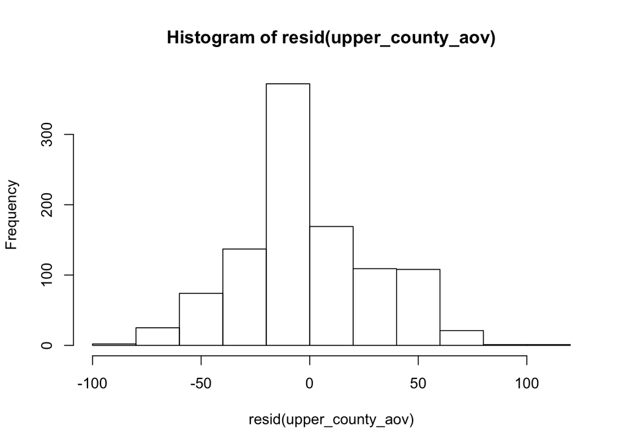

```r
hist(resid(upper_county_aov))
```

```r
#########################
#COUNTY: NON-PARAMETRIC
#########################
#KW-test: p = 0.0747
upper_county_kw <- kruskal.test(UPPER ~ COUNTY, data = upper_rural)




####################################
#MONTH
####################################
#p = 0.0555
upper_month_aov <- aov(UPPER ~ MONTH, data = upper_rural)
#p = 2.242e-14, not normal
shapiro.test((resid(upper_month_aov)))
```

```
##
##  Shapiro-Wilk normality test
##
## data:  (resid(upper_month_aov))
## W = 0.96726, p-value = 2.242e-14
```

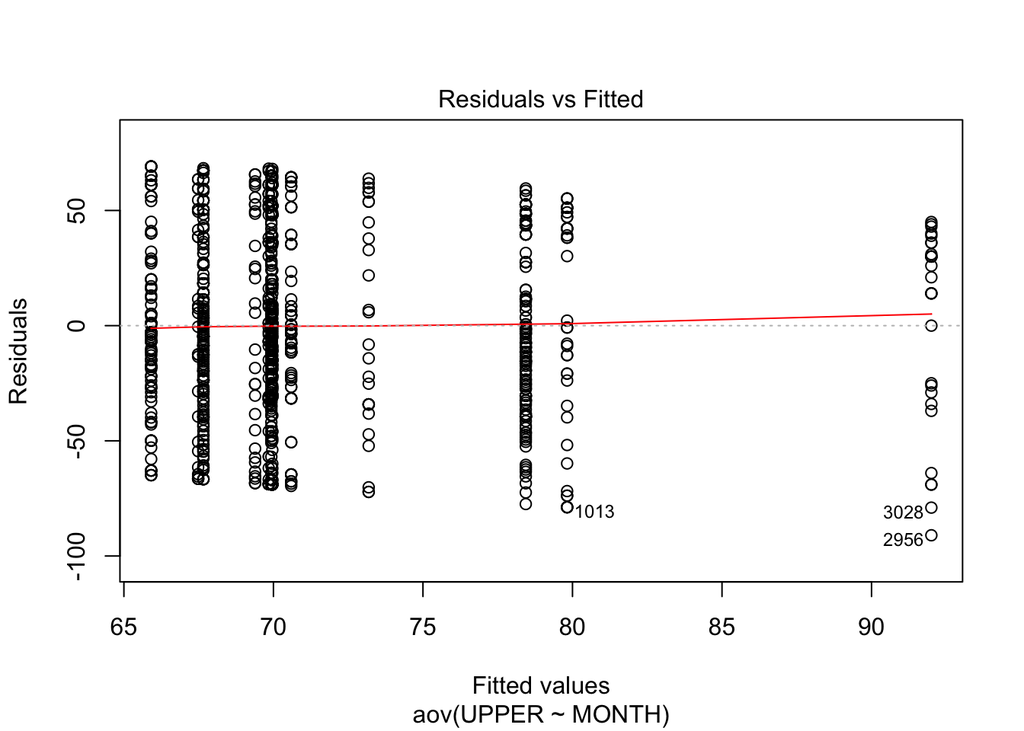

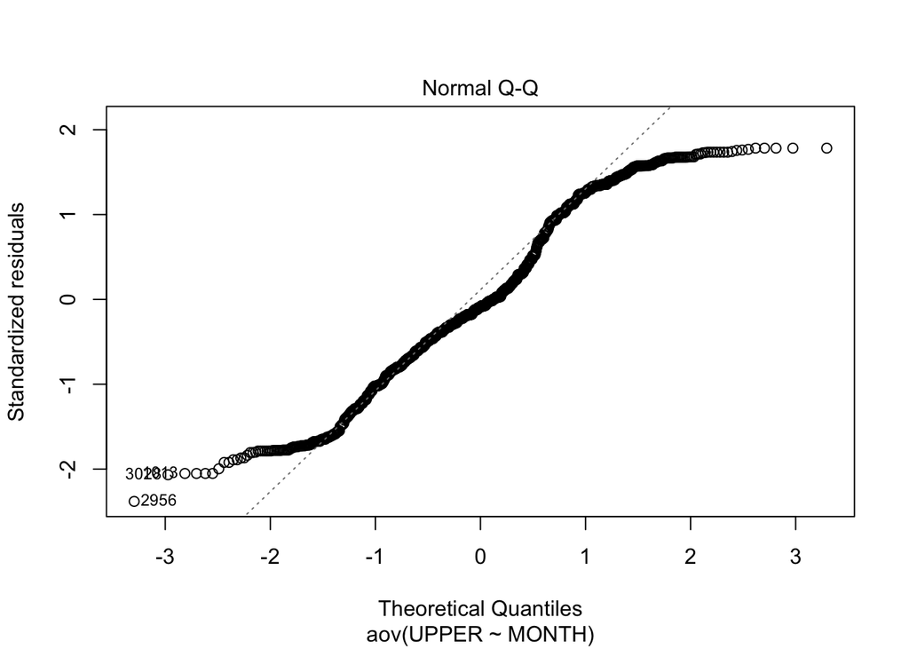

```r
plot(upper_month_aov, which = c(1,2))
```

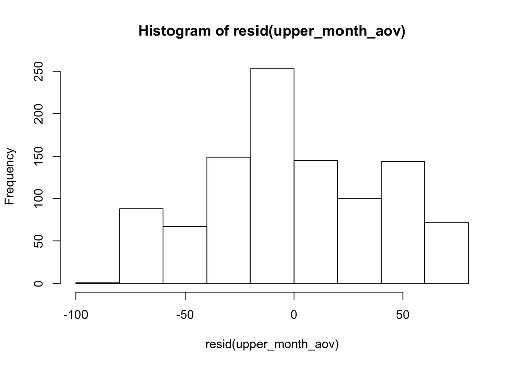

```r
hist(resid(upper_month_aov))
```

```r
#########################
#MONTH: NON-PARAMETRIC
#########################
#KW-test: p = 0.07786
upper_month_kw <- kruskal.test(UPPER ~ MONTH, data = upper_rural)




####################################
#TWO-WAY
####################################
#p = 0.0322
upper_twoway_aov <- aov(UPPER ~ COUNTY * MONTH, data = upper_rural)
#p = 6.897e-10, not normal
shapiro.test((resid(upper_county_aov)))
```

```
##
##  Shapiro-Wilk normality test
##
## data:  (resid(upper_county_aov))
## W = 0.98204, p-value = 6.897e-10
```

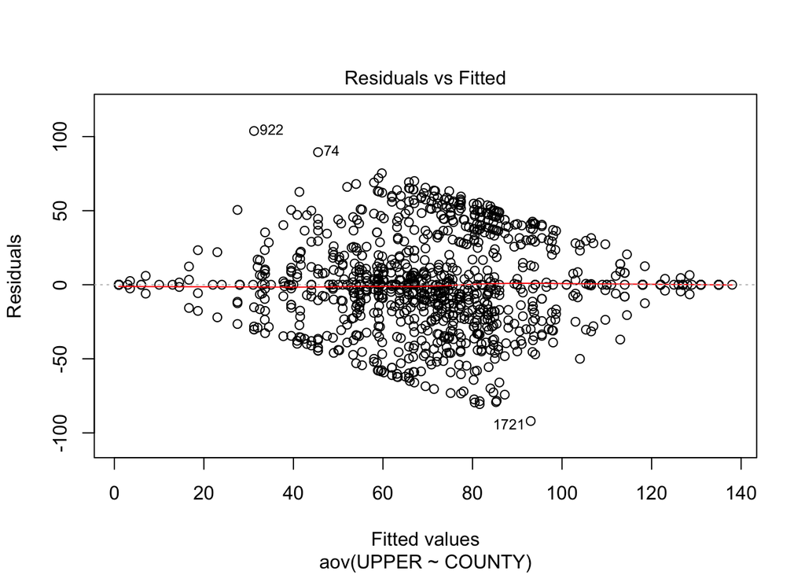

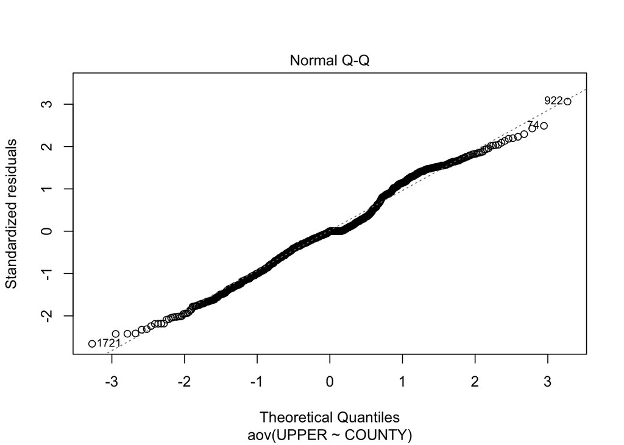

```r
plot(upper_county_aov, which = c(1,2))
```

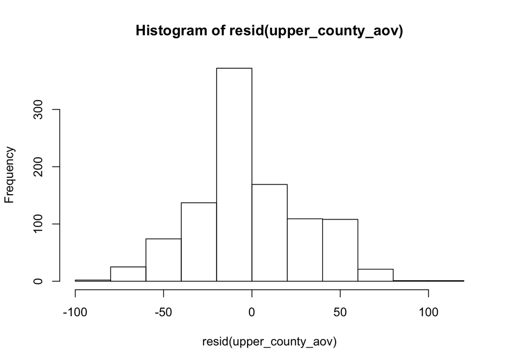

```r
hist(resid(upper_county_aov))
```

### Preliminary results

- Tried many transformations, but could not normalize data. Attempted a KW test for month and county.
- Just realized that I should do a ANOVA with upper quartile and then the factor being RMSP. Need to use all data.